# writeup

Zihan Fang

11/16/2020

# 1 Instruction

# 2 Background

Coverage probability is an important operating characteristic of methods for constructing interval estimates, particularly confidence intervals.

Definition: Define the 95% confidence interval of the median to be the middle 95% of sampling distribution of the median. Similarly, the 95% confidence interval of the mean, standard deviation, etc. is the middle 95% of the respective sampling distribution.

# 3 Methods

**STEPS**

**Step:** Generate a single sample from a standard normal distribution of size N=201. Explain to the reader how you use MLE to estimate the distribution.

First, I will generate a single sample from a standard normal distribution of size N=201 use `rnorm` function. We could use MLE to estimate the distribution of the single sample we generated before. And I will use `mean()` and `sqrt(((N-1)/N)*var(rnorm(N)))` functions to calculate its parameters. Then I use ’hist()` function to plot the sample and see if the sample fits the true distribution well. The graphic shows that it fits well.

We could also see that the the mean and standard deviation for the generated sample is about 0 and 1, but with slight difference.

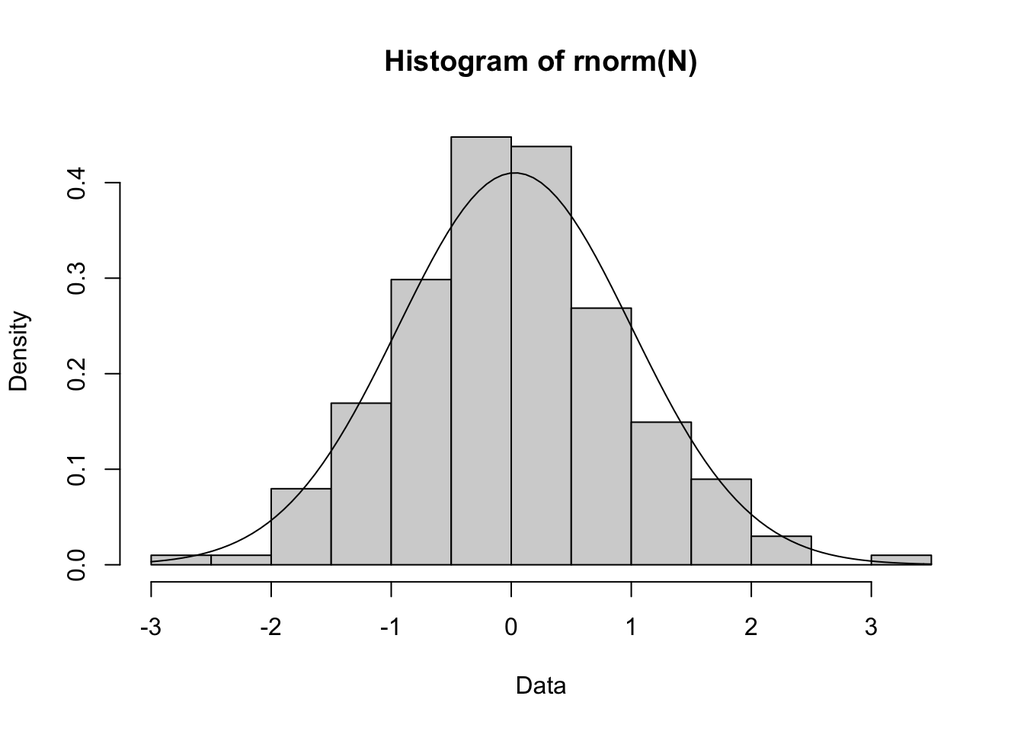

**Step:** Show the reader how you approximate the sampling distribution of the median, conditional on the estimate of the distribution in the previous step.

Then I will construct a confidence interval for the median. After using mle to estimate the mean and standard deviation of sample with size 201, we could use these parameters to generate sample and compute the median for this sample. Repeat this process 5000 times and we will get 5000 sample median. I approximate the sampling distribution of the median, conditional on the estimate of the distribution using `rbeta()%>% qnorm()`. Also, we will plot the medians to see the results.

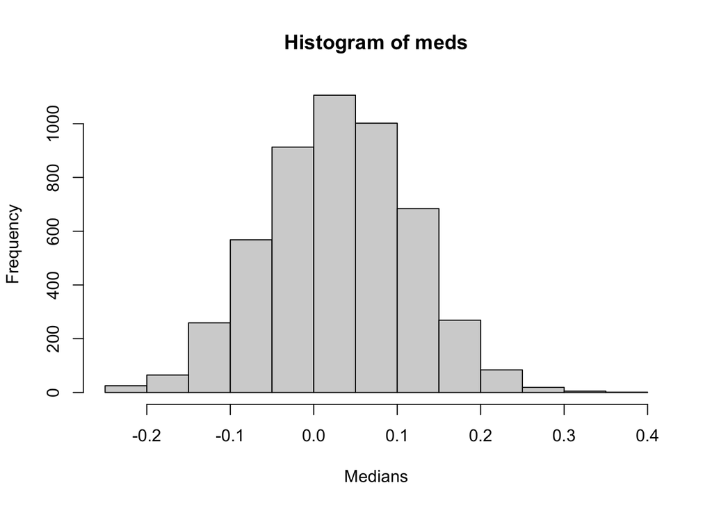

```r
meds=rbeta(5000,101,101)%>% qnorm(mean = mle.mean,sd=mle.sd)
hist(meds,xlab = "Medians")
```

**Step:** Describe how you calculate a 95% confidence interval from the approximated sampling distribution.

I use `quantile()` to calculate a 95% confidence interval. And I will define the 95% confidence interval of the median to be the middle 95% of sampling distribution of the median. The lower confidence limit for median is 0.025 quantile and the upper confidence limit for median is 0.975 quantile.

The median for standard normal distribution is 0. A confidence interval will capture median if the lower confidence limit is less than zero and the upper confidence limit is greater than zero. Then, I set a function to test whether the confidence interval captured the true median or not. The function will return `TRUE` if the confidence interval captured the true median and return `FALSE` if the confidence interval didn’t capture the true median.

```r
quantile(meds,c(0.025,0.975))
```

```
##       2.5%      97.5%
## -0.1383925  0.1959887
```

```r
ci= quantile(meds,c(0.025,0.975))
ci[1]<0 & ci[2]>0
```

```
## 2.5%
## TRUE
```

**Step:** Explain the concept of coverage probability. Explain your code for calculating the coverage probability.

```r
gen.ci.med = function(n=5000, N=201,parm.int=0){
  data=rnorm(N)
  mle.mean=mean(rnorm(N))
  mle.sd=sqrt(((N-1)/N)*var(rnorm(N)))
  meds=rbeta(n,101,101)%>% qnorm(mean = mle.mean,sd=mle.sd)
  ci= quantile(meds,c(0.025,0.975))
  return (ci[1]<parm.int & ci[2]>parm.int)
}
```

**Step:** Perform the simulation and report the results.

Now, I repeat the function which we generated before 1000 times and then compute the mean of captures as coverage probability.

```r
ci.contain=NA
for(i in 1:1000){
  ci.contain[i]=gen.ci.med()
}
mean(ci.contain)
```

```
## [1] 0.991
```

The coverage probability for 1000 simulation is 0.991. Idealy, a 95% confidence interval will capture the population parameter of interest in 95% of samples and our simulations perform a little bit better than 95%.

**Step:** Describe how you might change the simulation to learn more about the operating characteristics of your chosen method for constructing the 95% confidence interval.

```r
gen.ci.med = function(n=100, N=201,parm.int=0){
  data=rnorm(N)
  mle.mean=mean(rnorm(N))
  mle.sd=sqrt(((N-1)/N)*var(rnorm(N)))
  meds=rbeta(n,101,101)%>% qnorm(mean = mle.mean,sd=mle.sd)
  ci= quantile(meds,c(0.025,0.975))
  return (ci[1]<parm.int & ci[2]>parm.int)
}

ci.contain=NA
for(i in 1:100){
  ci.contain[i]=gen.ci.med()
}
mean(ci.contain)
```

```
## [1] 0.99
```